# Latihan M4

Natasha Muti Hafiza

2023-09-21

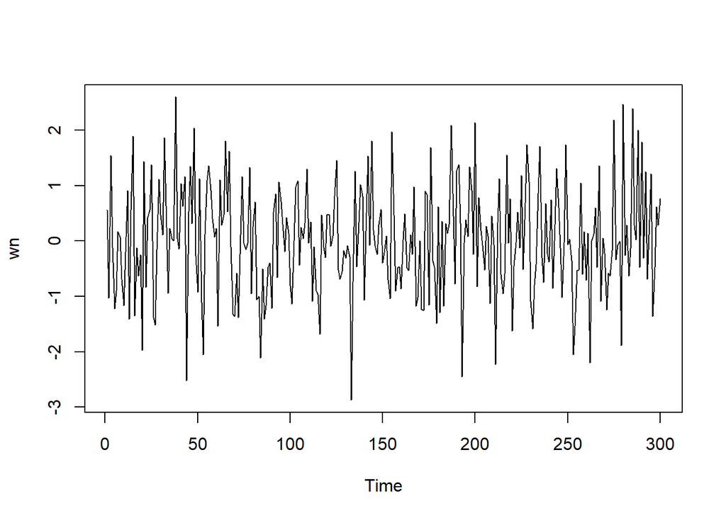

```r
set.seed(1019)
wn <- rnorm(300)
ts.plot(wn)
```

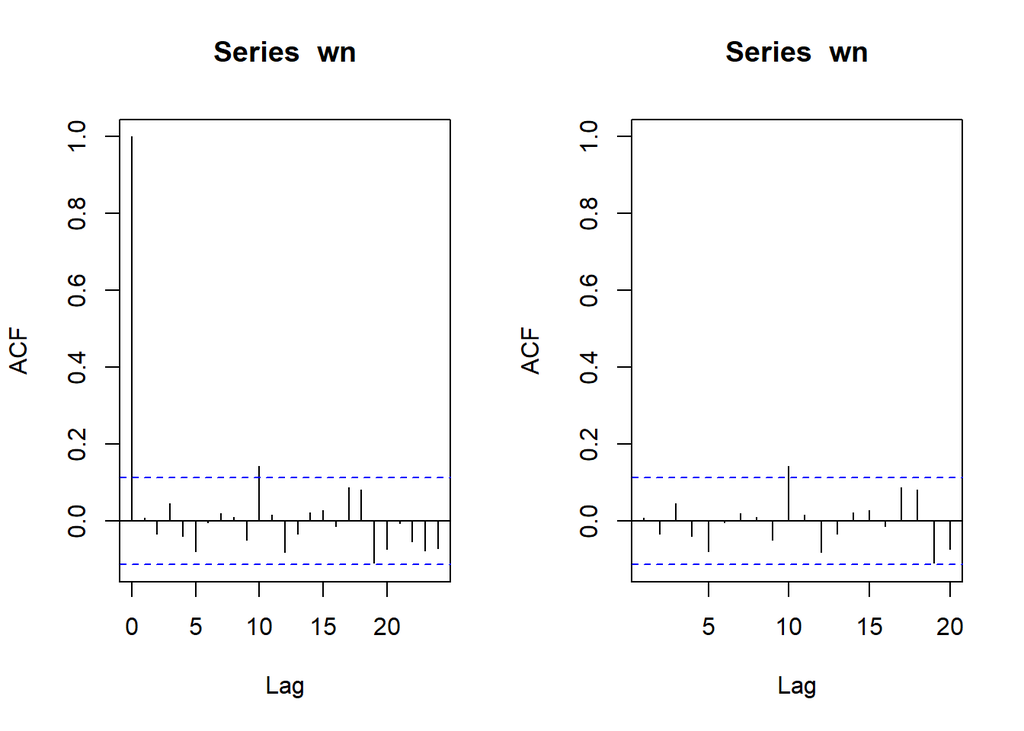

```r
par(mfrow = c(1, 2))
acf(wn)
acf(wn, xlim = c(1, 20))
```

## Pembangkitan Proses MA(2)

```r
set.seed(1019)
ma <- wn[1]
ma[2] <- wn[2]
```

$$y_t = e_t+0.4e_{t-1}+0.6e_{t-2}$$

```r
for(i in 3:300){
   ma[i] <- wn[i] + 0.4 * wn[i - 1] + 0.6 * wn[i - 2]
}
ma
```

```
##   [1]  0.561623272 -1.033676981  1.468644364 -0.113371792 -0.341350823
##   [6] -1.460588195 -0.926849287 -0.401545938 -0.559845173 -1.399592589
##  [11] -1.086633971  0.128871164 -1.170298611  0.544559543  1.273049951
##  [16] -0.254904982  0.476579545 -1.488438858 -0.579129510 -2.455817809
##  [21]  0.493058371 -1.450109560  0.948218735  0.227969609  1.850970507
##  [26] -0.491981576 -1.244748099 -1.583497651  0.141546439  0.830072482
##  [31]  0.968950714  2.190692212  1.447781334  0.432732439  0.236639063
##  [36] -0.424616855  0.160171256  2.629909915  1.088729663  1.435930572
##  [41]  1.002433201  0.956715347  2.033532465 -1.679390325  0.216762148
##  [46]  0.041631008  1.172004054  2.975249076  0.735712307  0.194612966
##  [51]  0.587376026 -1.214105521 -1.822801564 -1.367999372 -0.093643414
##  [56]  1.859302091  2.112278029  1.584276756  0.786296399  0.500448072
##  [61] -1.402787088  0.628611281 -0.194910951  1.249983325  2.164930102
##  [66]  1.531374005  2.916229985  0.859968708 -0.391053097 -1.950493758
##  [71] -1.922407198 -2.427768721 -1.143772489  0.234954583  0.280683704
```

[output cut: 45 more lines]

```r
set.seed(1019)
ma1 <- arima.sim(list(order=c(0,0,2), ma=c(0.4, 0.6)), n=300)
ma1
```

```
## Time Series:
## Start = 1
## End = 300
## Frequency = 1
##   [1]  1.468644364 -0.113371792 -0.341350823 -1.460588195 -0.926849287
##   [6] -0.401545938 -0.559845173 -1.399592589 -1.086633971  0.128871164
##  [11] -1.170298611  0.544559543  1.273049951 -0.254904982  0.476579545
##  [16] -1.488438858 -0.579129510 -2.455817809  0.493058371 -1.450109560
##  [21]  0.948218735  0.227969609  1.850970507 -0.491981576 -1.244748099
##  [26] -1.583497651  0.141546439  0.830072482  0.968950714  2.190692212
##  [31]  1.447781334  0.432732439  0.236639063 -0.424616855  0.160171256
##  [36]  2.629909915  1.088729663  1.435930572  1.002433201  0.956715347
##  [41]  2.033532465 -1.679390325  0.216762148  0.041631008  1.172004054
##  [46]  2.975249076  0.735712307  0.194612966  0.587376026 -1.214105521
##  [51] -1.822801564 -1.367999372 -0.093643414  1.859302091  2.112278029
```

[output cut: 49 more lines]

## Karakteristik MA(2)

### Plot Time Series

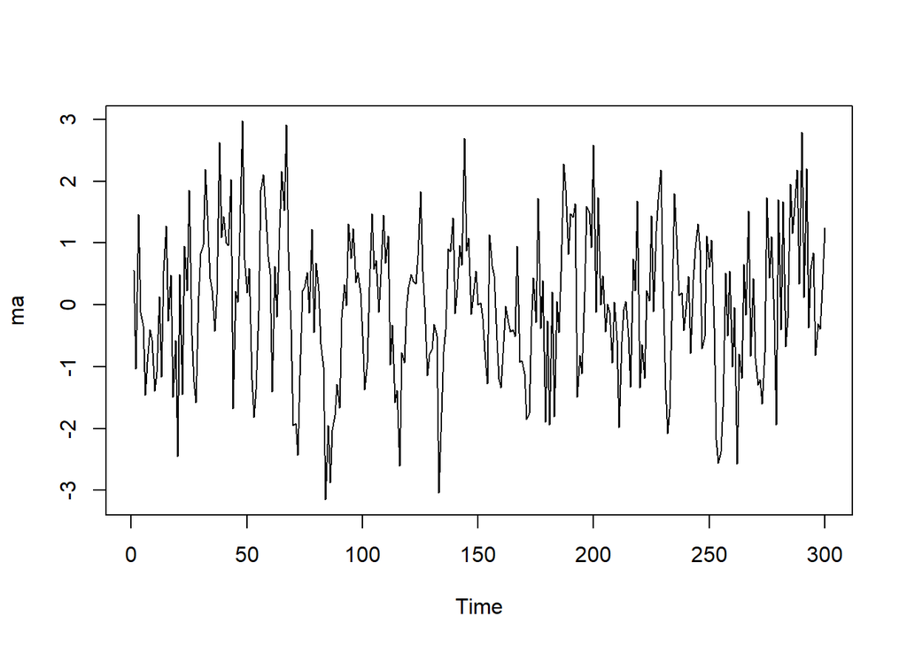

```r
ts.plot(ma)
```

Berdasarkan plot time series, terlihat bahwa data MA(2) yang dibangkitkan stasioner dalam rataan

### Plot ACF

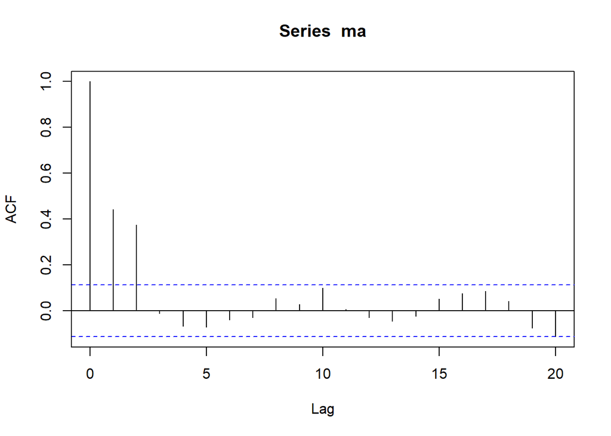

```r
acf(ma,lag.max = 20)
```

Berdasarkan plot AFC tersebut, terlihat bahwa plot ACF *cuts off* di lag kedua

### Plot PACF

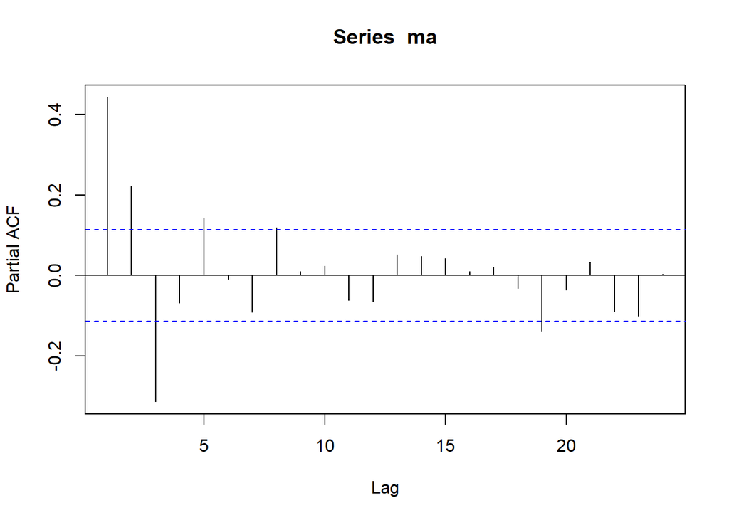

```r
pacf(ma)
```

Berdasarkan plot PACF tersebut, terlihat bahwa plot PACF cenderung *tails off* dan membentuk gelombang sinus

### Plot EACF

```r
TSA::eacf(ma)
```

```
## AR/MA
##   0 1 2 3 4 5 6 7 8 9 10 11 12 13
## 0 x x o o o o o o o o o  o  o  o
## 1 x x o o o o o o o o o  o  o  o
## 2 x x x o o o o o o o o  o  o  o
## 3 x x x x o o o o o o o  o  o  o
## 4 x x x o o x o o o o o  o  o  o
## 5 o x o o x x o o o x o  o  o  o
## 6 o x x o x x o o o x o  o  o  o
## 7 x x x x x x o o o o o  o  o  o
```

Berdasarkan pola segitiga nol pada plot EACF, terlihat bahwa segitiga nol berada pada ordo AR(0) dan ordo MA(2)

### Scatterplot Antar Lag

#### Scatterplot antara $Y_t$ dengan $Y_{t-1}$

```r
#Yt
yt_ma <- ma[c(-1,-2)]
yt_ma
```

```
##   [1]  1.468644364 -0.113371792 -0.341350823 -1.460588195 -0.926849287
##   [6] -0.401545938 -0.559845173 -1.399592589 -1.086633971  0.128871164
##  [11] -1.170298611  0.544559543  1.273049951 -0.254904982  0.476579545
##  [16] -1.488438858 -0.579129510 -2.455817809  0.493058371 -1.450109560
##  [21]  0.948218735  0.227969609  1.850970507 -0.491981576 -1.244748099
##  [26] -1.583497651  0.141546439  0.830072482  0.968950714  2.190692212
##  [31]  1.447781334  0.432732439  0.236639063 -0.424616855  0.160171256
##  [36]  2.629909915  1.088729663  1.435930572  1.002433201  0.956715347
##  [41]  2.033532465 -1.679390325  0.216762148  0.041631008  1.172004054
##  [46]  2.975249076  0.735712307  0.194612966  0.587376026 -1.214105521
##  [51] -1.822801564 -1.367999372 -0.093643414  1.859302091  2.112278029
##  [56]  1.584276756  0.786296399  0.500448072 -1.402787088  0.628611281
##  [61] -0.194910951  1.249983325  2.164930102  1.531374005  2.916229985
##  [66]  0.859968708 -0.391053097 -1.950493758 -1.922407198 -2.427768721
##  [71] -1.143772489  0.234954583  0.280683704  0.524947446 -0.130293119
```

[output cut: 45 more lines]

```r
#Yt-1
yt_1_ma <- ma[c(-299,-300)]
yt_1_ma
```

```
##   [1]  0.561623272 -1.033676981  1.468644364 -0.113371792 -0.341350823
##   [6] -1.460588195 -0.926849287 -0.401545938 -0.559845173 -1.399592589
##  [11] -1.086633971  0.128871164 -1.170298611  0.544559543  1.273049951
##  [16] -0.254904982  0.476579545 -1.488438858 -0.579129510 -2.455817809
##  [21]  0.493058371 -1.450109560  0.948218735  0.227969609  1.850970507
##  [26] -0.491981576 -1.244748099 -1.583497651  0.141546439  0.830072482
##  [31]  0.968950714  2.190692212  1.447781334  0.432732439  0.236639063
##  [36] -0.424616855  0.160171256  2.629909915  1.088729663  1.435930572
##  [41]  1.002433201  0.956715347  2.033532465 -1.679390325  0.216762148
##  [46]  0.041631008  1.172004054  2.975249076  0.735712307  0.194612966
##  [51]  0.587376026 -1.214105521 -1.822801564 -1.367999372 -0.093643414
##  [56]  1.859302091  2.112278029  1.584276756  0.786296399  0.500448072
##  [61] -1.402787088  0.628611281 -0.194910951  1.249983325  2.164930102
##  [66]  1.531374005  2.916229985  0.859968708 -0.391053097 -1.950493758
##  [71] -1.922407198 -2.427768721 -1.143772489  0.234954583  0.280683704
```

[output cut: 45 more lines]

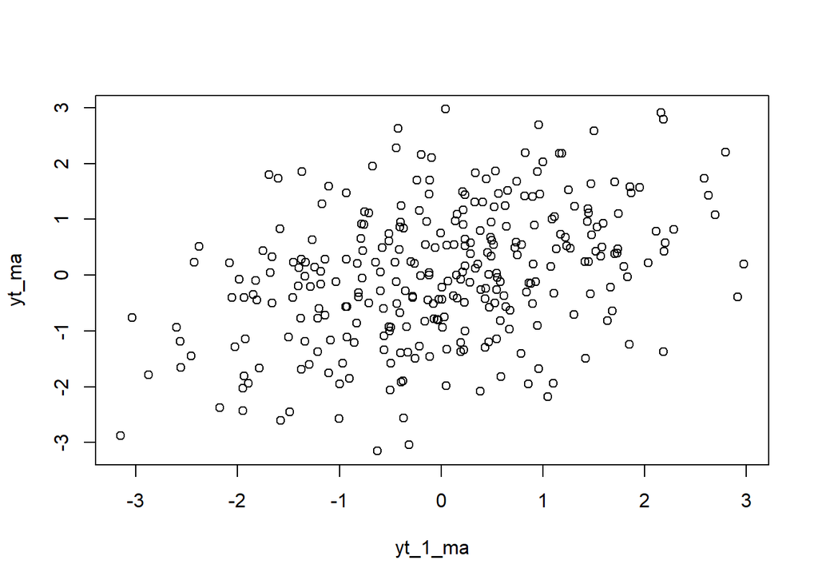

```r
plot(y=yt_ma,x=yt_1_ma)
```

Berdasarkan scatterplot tersebut, terlihat bahwa terdapat hubungan positif antara $Y_t$ dengan $Y_{t-1}$. Hal ini sesuai dengan teori yang ada

#### Korelasi antara $Y_t$ dengan $Y_{t-2}$

```r
#Yt
yt_ma2 <- ma[-c(1,2,3)]
yt_ma2
```

```
##   [1] -0.113371792 -0.341350823 -1.460588195 -0.926849287 -0.401545938
##   [6] -0.559845173 -1.399592589 -1.086633971  0.128871164 -1.170298611
##  [11]  0.544559543  1.273049951 -0.254904982  0.476579545 -1.488438858
##  [16] -0.579129510 -2.455817809  0.493058371 -1.450109560  0.948218735
##  [21]  0.227969609  1.850970507 -0.491981576 -1.244748099 -1.583497651
##  [26]  0.141546439  0.830072482  0.968950714  2.190692212  1.447781334
##  [31]  0.432732439  0.236639063 -0.424616855  0.160171256  2.629909915
##  [36]  1.088729663  1.435930572  1.002433201  0.956715347  2.033532465
##  [41] -1.679390325  0.216762148  0.041631008  1.172004054  2.975249076
##  [46]  0.735712307  0.194612966  0.587376026 -1.214105521 -1.822801564
##  [51] -1.367999372 -0.093643414  1.859302091  2.112278029  1.584276756
##  [56]  0.786296399  0.500448072 -1.402787088  0.628611281 -0.194910951
##  [61]  1.249983325  2.164930102  1.531374005  2.916229985  0.859968708
##  [66] -0.391053097 -1.950493758 -1.922407198 -2.427768721 -1.143772489
##  [71]  0.234954583  0.280683704  0.524947446 -0.130293119  1.219786209
```

[output cut: 45 more lines]

```r
#Yt-2
yt_2_ma <- ma[-c(298,299,300)]
yt_2_ma
```

```
##   [1]  0.561623272 -1.033676981  1.468644364 -0.113371792 -0.341350823
##   [6] -1.460588195 -0.926849287 -0.401545938 -0.559845173 -1.399592589
##  [11] -1.086633971  0.128871164 -1.170298611  0.544559543  1.273049951
##  [16] -0.254904982  0.476579545 -1.488438858 -0.579129510 -2.455817809
##  [21]  0.493058371 -1.450109560  0.948218735  0.227969609  1.850970507
##  [26] -0.491981576 -1.244748099 -1.583497651  0.141546439  0.830072482
##  [31]  0.968950714  2.190692212  1.447781334  0.432732439  0.236639063
##  [36] -0.424616855  0.160171256  2.629909915  1.088729663  1.435930572
##  [41]  1.002433201  0.956715347  2.033532465 -1.679390325  0.216762148
##  [46]  0.041631008  1.172004054  2.975249076  0.735712307  0.194612966
##  [51]  0.587376026 -1.214105521 -1.822801564 -1.367999372 -0.093643414
##  [56]  1.859302091  2.112278029  1.584276756  0.786296399  0.500448072
##  [61] -1.402787088  0.628611281 -0.194910951  1.249983325  2.164930102
##  [66]  1.531374005  2.916229985  0.859968708 -0.391053097 -1.950493758
##  [71] -1.922407198 -2.427768721 -1.143772489  0.234954583  0.280683704
```

[output cut: 45 more lines]

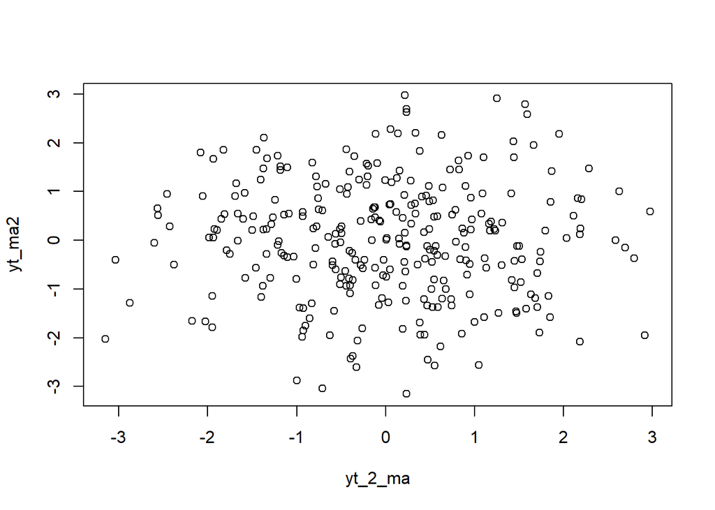

```r
plot(y=yt_ma2,x=yt_2_ma)
```

#### Korelasi antara $Y_t$ dengan $Y_{t-3}$

```r
#Yt
yt_ma3 <- ma[-c(1,2,3,4)]
yt_ma3
```

```
##   [1] -0.341350823 -1.460588195 -0.926849287 -0.401545938 -0.559845173
##   [6] -1.399592589 -1.086633971  0.128871164 -1.170298611  0.544559543
##  [11]  1.273049951 -0.254904982  0.476579545 -1.488438858 -0.579129510
##  [16] -2.455817809  0.493058371 -1.450109560  0.948218735  0.227969609
##  [21]  1.850970507 -0.491981576 -1.244748099 -1.583497651  0.141546439
##  [26]  0.830072482  0.968950714  2.190692212  1.447781334  0.432732439
##  [31]  0.236639063 -0.424616855  0.160171256  2.629909915  1.088729663
##  [36]  1.435930572  1.002433201  0.956715347  2.033532465 -1.679390325
##  [41]  0.216762148  0.041631008  1.172004054  2.975249076  0.735712307
##  [46]  0.194612966  0.587376026 -1.214105521 -1.822801564 -1.367999372
##  [51] -0.093643414  1.859302091  2.112278029  1.584276756  0.786296399
##  [56]  0.500448072 -1.402787088  0.628611281 -0.194910951  1.249983325
##  [61]  2.164930102  1.531374005  2.916229985  0.859968708 -0.391053097
##  [66] -1.950493758 -1.922407198 -2.427768721 -1.143772489  0.234954583
##  [71]  0.280683704  0.524947446 -0.130293119  1.219786209 -0.450301631
```

[output cut: 45 more lines]

```r
#Yt-2
yt_3_ma <- ma[-c(297,298,299,300)]
yt_3_ma
```

```
##   [1]  0.561623272 -1.033676981  1.468644364 -0.113371792 -0.341350823
##   [6] -1.460588195 -0.926849287 -0.401545938 -0.559845173 -1.399592589
##  [11] -1.086633971  0.128871164 -1.170298611  0.544559543  1.273049951
##  [16] -0.254904982  0.476579545 -1.488438858 -0.579129510 -2.455817809
##  [21]  0.493058371 -1.450109560  0.948218735  0.227969609  1.850970507
##  [26] -0.491981576 -1.244748099 -1.583497651  0.141546439  0.830072482
##  [31]  0.968950714  2.190692212  1.447781334  0.432732439  0.236639063
##  [36] -0.424616855  0.160171256  2.629909915  1.088729663  1.435930572
##  [41]  1.002433201  0.956715347  2.033532465 -1.679390325  0.216762148
##  [46]  0.041631008  1.172004054  2.975249076  0.735712307  0.194612966
##  [51]  0.587376026 -1.214105521 -1.822801564 -1.367999372 -0.093643414
##  [56]  1.859302091  2.112278029  1.584276756  0.786296399  0.500448072
##  [61] -1.402787088  0.628611281 -0.194910951  1.249983325  2.164930102
##  [66]  1.531374005  2.916229985  0.859968708 -0.391053097 -1.950493758
##  [71] -1.922407198 -2.427768721 -1.143772489  0.234954583  0.280683704
```

[output cut: 45 more lines]

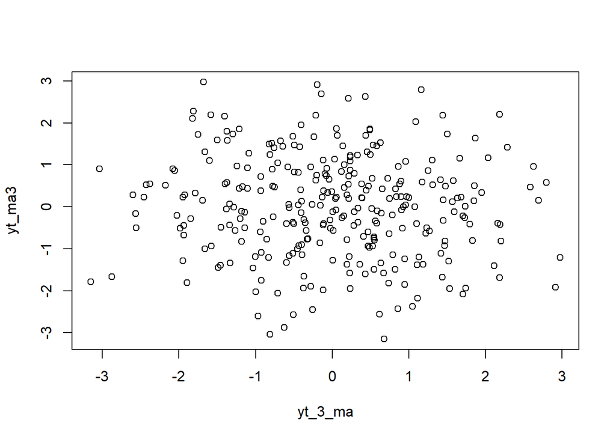

```r
plot(y=yt_ma3,x=yt_3_ma)
```

Berdasarkan scatterplot tersebut, terlihat bahwa cenderung tidak terdapat hubungan antara $Y_t$ dengan $Y_{t-3}$.

## Pembangkitan Proses AR

```r
set.seed(1019)
```

$$Y_t = e_t+0.5Y_{t-1}+0.2Y_{t-2}$$

```r
set.seed(1019)
n<-length(wn)
n
```

```
## [1] 300
```

```r
ar <- c(1:n)
for (i in 3:n) {ar[i]<-wn[i]+0.5*ar[i-1]+0.2*ar[i-2]}
ar
```

```
##   [1]  1.000000000  2.000000000  2.745141193  1.661348515  0.155755790
##   [6] -0.494128666 -0.046683933 -0.048839576 -0.724470542 -1.539307063
##  [11] -1.119831679  0.043589853 -1.613846439 -0.235795957  1.454423985
##  [16] -0.670334256 -0.164602714 -0.846446678 -0.711049774 -2.500622592
##  [21]  0.043804003 -1.317377156 -0.227842339  0.185231617  1.419715297
##  [26] -0.631721717 -1.548816396 -1.050315341  0.276589768  0.403437691
##  [31]  0.368998732  2.125970817  1.773075763  0.373477893  0.771520458
##  [36]  0.506724900  0.411230346  2.907683091  1.582389820  1.229707456
##  [41]  1.963193198  1.857323278  2.483801765 -0.908896494  0.570478175
##  [46]  1.447181589  1.155302121  2.909057097  1.413943977  0.366872541
##  [51]  1.585352436 -0.242559222 -1.855043130 -0.858533210  0.289581679
##  [56]  1.325943405  1.638108239  1.489915952  1.146274641  1.098686685
##  [61] -0.759432297  0.947304992  0.606759905  0.964456446  2.408867787
##  [66]  1.923614858  3.066122552  1.812962524  0.197056425 -0.897420268
##  [71] -0.994700045 -2.055317728 -1.467737184  0.013567961 -0.324796805
```

[output cut: 45 more lines]

Selain menggunakan cara di atas, pembangkitan proses AR dapat dilakukan dengan fungsi `arima.sim()` sebagai berikut.

```r
set.seed(1019)
ar1 <- arima.sim(list(order=c(2,0,0), ar= c(0.5, 0.2)), n=300)
ar1
```

```
## Time Series:
## Start = 1
## End = 300
## Frequency = 1
##   [1] -0.634889754 -1.551231541 -1.052156521  0.275186149  0.402367645
##   [6]  0.368182986  2.125348935  1.772601673  0.373116471  0.771244929
##  [11]  0.506514851  0.411070216  2.907561016  1.582296756  1.229636509
##  [16]  1.963139112  1.857282045  2.483770331 -0.908920458  0.570459907
##  [21]  1.447167662  1.155291504  2.909049003  1.413937807  0.366867837
##  [26]  1.585348850 -0.242561956 -1.855045214 -0.858534799  0.289580468
##  [31]  1.325942481  1.638107535  1.489915415  1.146274232  1.098686373
##  [36] -0.759432535  0.947304811  0.606759767  0.964456341  2.408867706
##  [41]  1.923614796  3.066122505  1.812962489  0.197056398 -0.897420289
##  [46] -0.994700060 -2.055317740 -1.467737193  0.013567954 -0.324796810
##  [51] -0.314624088 -0.267768807  1.134139512 -0.441866689  0.265425507
```

[output cut: 49 more lines]

## Karakteristik AR(2)

### Plot Time Series

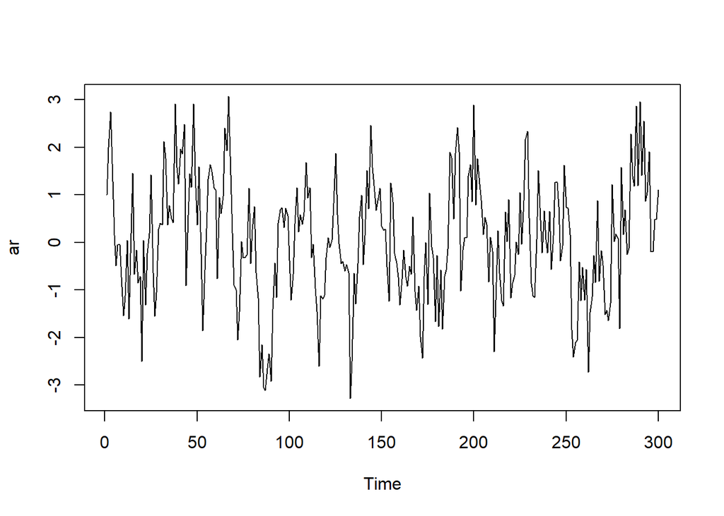

```r
ts.plot(ar)
```

Berdasarkan plot time series tersebut terlihat bahwa data cenderung stasioner pada rataan

### Plot ACF

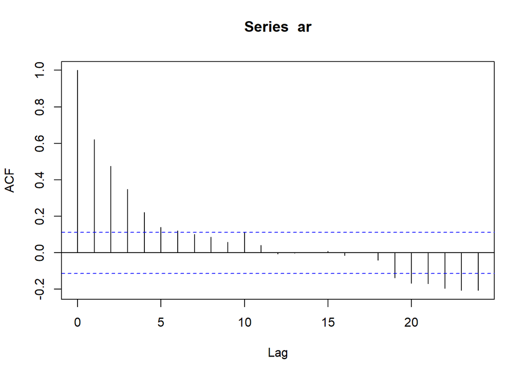

```r
acf(ar)
```

Berdasarkan plot ACF tersebut terlihat bahwa plot ACF cenderung *tails off* dan cenderung membentuk pola grafik sinus

### Plot PACF

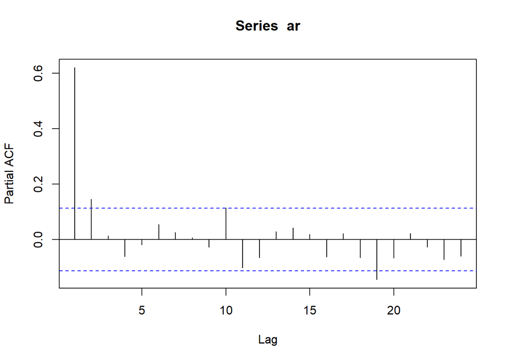

```r
pacf(ar)
```

Berdasarkan plot PACF tersebut, terlihat bahwa plot PACF *cuts off* pada lag kedua, sejalan dengan teori yang ada

### Plot EACF

```r
TSA::eacf(ar)
```

```
## AR/MA
##   0 1 2 3 4 5 6 7 8 9 10 11 12 13
## 0 x x x x x x o o o o o  o  o  o
## 1 x o o o o o o o o x o  o  o  o
## 2 x o o o o o o o o x o  o  o  o
## 3 x x o o o o o o o x o  o  o  o
## 4 x x o o o o o o o x o  o  o  o
## 5 x x o x o o o o o x o  o  o  o
## 6 x o x x o o o o o x o  o  o  o
## 7 x o o x o o o o o o o  o  o  o
```

Berdasarkan pola segitiga nol pada plot EACF, terlihat bahwa segitiga nol berada pada ordo AR(1) dan ordo MA(1)

### Scatterplot Antar Lag

#### Scatterplot antara $Y_t$ dengan $Y_{t-1}$

```r
#Yt
yt_ar <- ar[c(-1,-2)]
yt_ar
```

```
##   [1]  2.745141193  1.661348515  0.155755790 -0.494128666 -0.046683933
##   [6] -0.048839576 -0.724470542 -1.539307063 -1.119831679  0.043589853
##  [11] -1.613846439 -0.235795957  1.454423985 -0.670334256 -0.164602714
##  [16] -0.846446678 -0.711049774 -2.500622592  0.043804003 -1.317377156
##  [21] -0.227842339  0.185231617  1.419715297 -0.631721717 -1.548816396
##  [26] -1.050315341  0.276589768  0.403437691  0.368998732  2.125970817
##  [31]  1.773075763  0.373477893  0.771520458  0.506724900  0.411230346
##  [36]  2.907683091  1.582389820  1.229707456  1.963193198  1.857323278
##  [41]  2.483801765 -0.908896494  0.570478175  1.447181589  1.155302121
##  [46]  2.909057097  1.413943977  0.366872541  1.585352436 -0.242559222
##  [51] -1.855043130 -0.858533210  0.289581679  1.325943405  1.638108239
##  [56]  1.489915952  1.146274641  1.098686685 -0.759432297  0.947304992
##  [61]  0.606759905  0.964456446  2.408867787  1.923614858  3.066122552
##  [66]  1.812962524  0.197056425 -0.897420268 -0.994700045 -2.055317728
##  [71] -1.467737184  0.013567961 -0.324796805 -0.314624084 -0.267768804
```

[output cut: 45 more lines]

```r
#Yt-1
yt_1_ar <- ar[c(-299,-300)]
yt_1_ar
```

```
##   [1]  1.000000000  2.000000000  2.745141193  1.661348515  0.155755790
##   [6] -0.494128666 -0.046683933 -0.048839576 -0.724470542 -1.539307063
##  [11] -1.119831679  0.043589853 -1.613846439 -0.235795957  1.454423985
##  [16] -0.670334256 -0.164602714 -0.846446678 -0.711049774 -2.500622592
##  [21]  0.043804003 -1.317377156 -0.227842339  0.185231617  1.419715297
##  [26] -0.631721717 -1.548816396 -1.050315341  0.276589768  0.403437691
##  [31]  0.368998732  2.125970817  1.773075763  0.373477893  0.771520458
##  [36]  0.506724900  0.411230346  2.907683091  1.582389820  1.229707456
##  [41]  1.963193198  1.857323278  2.483801765 -0.908896494  0.570478175
##  [46]  1.447181589  1.155302121  2.909057097  1.413943977  0.366872541
##  [51]  1.585352436 -0.242559222 -1.855043130 -0.858533210  0.289581679
##  [56]  1.325943405  1.638108239  1.489915952  1.146274641  1.098686685
##  [61] -0.759432297  0.947304992  0.606759905  0.964456446  2.408867787
##  [66]  1.923614858  3.066122552  1.812962524  0.197056425 -0.897420268
##  [71] -0.994700045 -2.055317728 -1.467737184  0.013567961 -0.324796805
```

[output cut: 45 more lines]

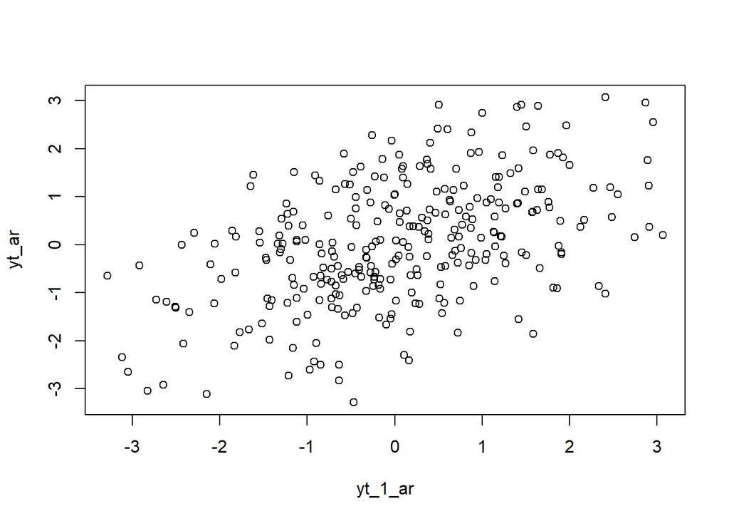

```r
plot(y=yt_ar,x=yt_1_ar)
```

Berdasarkan scatterplot tersebut, terlihat bahwa terdapat hubungan positif antara $Y_t$ dengan $Y_{t-1}$. Hal ini sesuai dengan teori yang ada

#### Korelasi antara $Y_t$ dengan $Y_{t-2}$

```r
#Yt
yt_ar2 <- ar[-c(1,2,3)]
yt_ar2
```

```
##   [1]  1.661348515  0.155755790 -0.494128666 -0.046683933 -0.048839576
##   [6] -0.724470542 -1.539307063 -1.119831679  0.043589853 -1.613846439
##  [11] -0.235795957  1.454423985 -0.670334256 -0.164602714 -0.846446678
##  [16] -0.711049774 -2.500622592  0.043804003 -1.317377156 -0.227842339
##  [21]  0.185231617  1.419715297 -0.631721717 -1.548816396 -1.050315341
##  [26]  0.276589768  0.403437691  0.368998732  2.125970817  1.773075763
##  [31]  0.373477893  0.771520458  0.506724900  0.411230346  2.907683091
##  [36]  1.582389820  1.229707456  1.963193198  1.857323278  2.483801765
##  [41] -0.908896494  0.570478175  1.447181589  1.155302121  2.909057097
##  [46]  1.413943977  0.366872541  1.585352436 -0.242559222 -1.855043130
##  [51] -0.858533210  0.289581679  1.325943405  1.638108239  1.489915952
##  [56]  1.146274641  1.098686685 -0.759432297  0.947304992  0.606759905
##  [61]  0.964456446  2.408867787  1.923614858  3.066122552  1.812962524
##  [66]  0.197056425 -0.897420268 -0.994700045 -2.055317728 -1.467737184
##  [71]  0.013567961 -0.324796805 -0.314624084 -0.267768804  1.134139515
```

[output cut: 45 more lines]

```r
#Yt-2
yt_2_ar <- ar[-c(298,299,300)]
yt_2_ar
```

```
##   [1]  1.000000000  2.000000000  2.745141193  1.661348515  0.155755790
##   [6] -0.494128666 -0.046683933 -0.048839576 -0.724470542 -1.539307063
##  [11] -1.119831679  0.043589853 -1.613846439 -0.235795957  1.454423985
##  [16] -0.670334256 -0.164602714 -0.846446678 -0.711049774 -2.500622592
##  [21]  0.043804003 -1.317377156 -0.227842339  0.185231617  1.419715297
##  [26] -0.631721717 -1.548816396 -1.050315341  0.276589768  0.403437691
##  [31]  0.368998732  2.125970817  1.773075763  0.373477893  0.771520458
##  [36]  0.506724900  0.411230346  2.907683091  1.582389820  1.229707456
##  [41]  1.963193198  1.857323278  2.483801765 -0.908896494  0.570478175
##  [46]  1.447181589  1.155302121  2.909057097  1.413943977  0.366872541
##  [51]  1.585352436 -0.242559222 -1.855043130 -0.858533210  0.289581679
##  [56]  1.325943405  1.638108239  1.489915952  1.146274641  1.098686685
##  [61] -0.759432297  0.947304992  0.606759905  0.964456446  2.408867787
##  [66]  1.923614858  3.066122552  1.812962524  0.197056425 -0.897420268
##  [71] -0.994700045 -2.055317728 -1.467737184  0.013567961 -0.324796805
```

[output cut: 45 more lines]

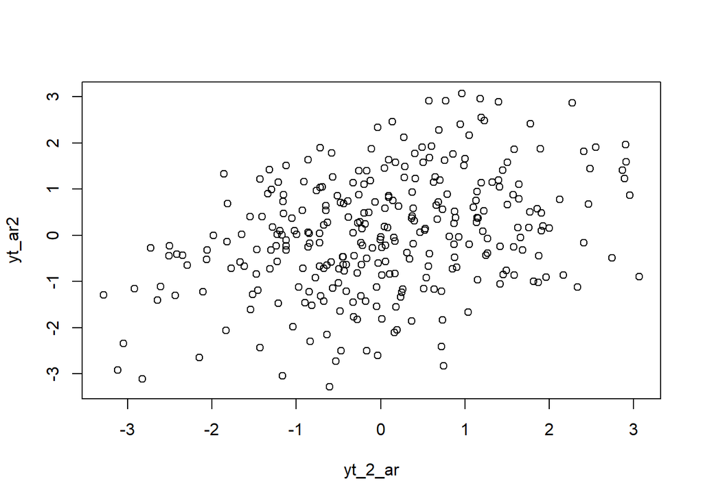

```r
plot(y=yt_ar2,x=yt_2_ar)
```

Berdasarkan scatterplot tersebut, terlihat bahwa terdapat hubungan positif antara $Y_t$ dengan $Y_{t-2}$. Hal ini sesuai dengan teori yang ada

#### Korelasi antara $Y_t$ dengan $Y_{t-3}$

```r
#Yt
yt_ar3 <- ar[-c(1,2,3,4)]
yt_ar3
```

```
##   [1]  0.155755790 -0.494128666 -0.046683933 -0.048839576 -0.724470542
##   [6] -1.539307063 -1.119831679  0.043589853 -1.613846439 -0.235795957
##  [11]  1.454423985 -0.670334256 -0.164602714 -0.846446678 -0.711049774
##  [16] -2.500622592  0.043804003 -1.317377156 -0.227842339  0.185231617
##  [21]  1.419715297 -0.631721717 -1.548816396 -1.050315341  0.276589768
##  [26]  0.403437691  0.368998732  2.125970817  1.773075763  0.373477893
##  [31]  0.771520458  0.506724900  0.411230346  2.907683091  1.582389820
##  [36]  1.229707456  1.963193198  1.857323278  2.483801765 -0.908896494
##  [41]  0.570478175  1.447181589  1.155302121  2.909057097  1.413943977
##  [46]  0.366872541  1.585352436 -0.242559222 -1.855043130 -0.858533210
##  [51]  0.289581679  1.325943405  1.638108239  1.489915952  1.146274641
##  [56]  1.098686685 -0.759432297  0.947304992  0.606759905  0.964456446
##  [61]  2.408867787  1.923614858  3.066122552  1.812962524  0.197056425
##  [66] -0.897420268 -0.994700045 -2.055317728 -1.467737184  0.013567961
##  [71] -0.324796805 -0.314624084 -0.267768804  1.134139515 -0.441866688
```

[output cut: 45 more lines]

```r
#Yt-2
yt_3_ar <- ar[-c(297,298,299,300)]
yt_3_ar
```

```
##   [1]  1.000000000  2.000000000  2.745141193  1.661348515  0.155755790
##   [6] -0.494128666 -0.046683933 -0.048839576 -0.724470542 -1.539307063
##  [11] -1.119831679  0.043589853 -1.613846439 -0.235795957  1.454423985
##  [16] -0.670334256 -0.164602714 -0.846446678 -0.711049774 -2.500622592
##  [21]  0.043804003 -1.317377156 -0.227842339  0.185231617  1.419715297
##  [26] -0.631721717 -1.548816396 -1.050315341  0.276589768  0.403437691
##  [31]  0.368998732  2.125970817  1.773075763  0.373477893  0.771520458
##  [36]  0.506724900  0.411230346  2.907683091  1.582389820  1.229707456
##  [41]  1.963193198  1.857323278  2.483801765 -0.908896494  0.570478175
##  [46]  1.447181589  1.155302121  2.909057097  1.413943977  0.366872541
##  [51]  1.585352436 -0.242559222 -1.855043130 -0.858533210  0.289581679
##  [56]  1.325943405  1.638108239  1.489915952  1.146274641  1.098686685
##  [61] -0.759432297  0.947304992  0.606759905  0.964456446  2.408867787
##  [66]  1.923614858  3.066122552  1.812962524  0.197056425 -0.897420268
##  [71] -0.994700045 -2.055317728 -1.467737184  0.013567961 -0.324796805
```

[output cut: 45 more lines]

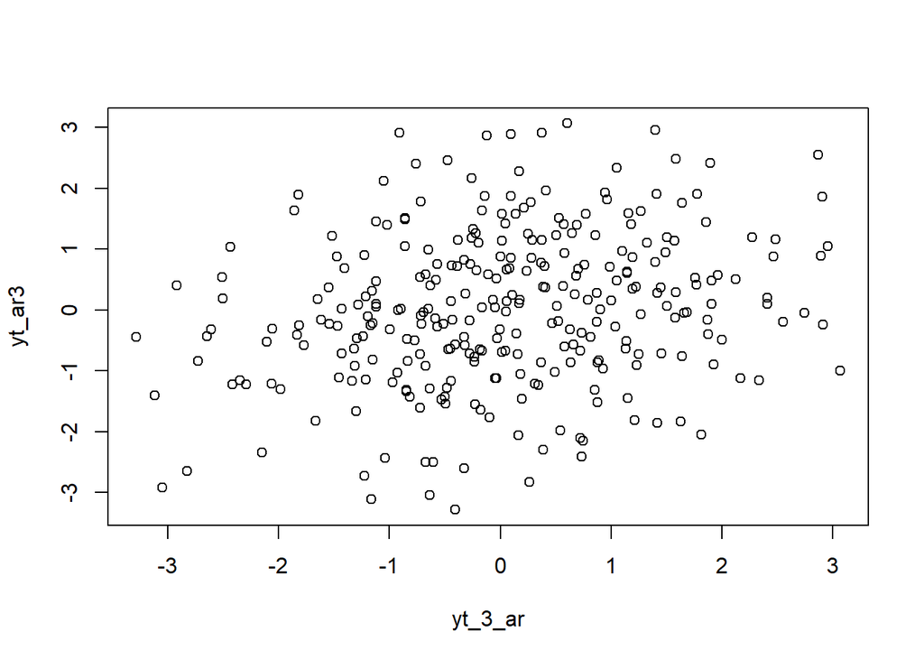

```r
plot(y=yt_ar3,x=yt_3_ar)
```

Berdasarkan scatterplot tersebut, terlihat bahwa terdapat hubungan positif antara $Y_t$ dengan $Y_{t-3}$. Hal ini sesuai dengan teori yang ada

## Fungsi pembangkitan ARMA

Pertama, lihat kembali bentuk umum data berpola ARMA.

```r
set.seed(1019)
n = length(wn)
phi1 = 0.5
phi2 = 0.2
theta1 = 0.4
theta2 = 0.6

y.arma=c(1:n)
for (i in 3:n){y.arma[i] = phi1*y.arma[i-1] + phi2*y.arma[i-2] + theta1*wn[i-1]+wn[i] + theta2*wn[i-2]+wn[i]}
y.arma
```

```
##   [1]  1.000000000  2.000000000  4.213785558  2.282298905  0.418609035
##   [6] -1.699100161 -1.523448318 -1.429762005 -2.270129807 -3.987913771
##  [11] -3.739900857 -1.627294913 -4.143601269 -1.290290783  1.694275557
##  [16] -1.016212418  0.187008064 -2.228255779 -1.910761678 -5.832658173
##  [21] -1.369097798 -4.140344732 -0.973687753 -0.524314996  2.766743415
##  [26] -0.592098556 -2.504347291 -3.103653807 -0.799639205  0.284727993
##  [31]  1.063348802  4.640096125  4.616789765  2.730892395  2.755609572
##  [36]  1.545635502  1.487674726  6.283597316  4.574365472  4.836808699
##  [41]  5.367572151  5.237648349  6.888372556  0.290063590  2.267634524
##  [46]  2.577182788  3.231738044  7.148524374  4.684677108  3.044745528
##  [51]  4.165811582  0.369139427 -2.855903540 -2.604623057 -0.877278740
##  [56]  2.252597316  3.980341140  4.430639941  3.871379615  3.549832042
##  [61] -0.391625712  2.250048637  1.136782093  2.739999594  5.567573900
##  [66]  5.389450549  8.347011605  6.006542898  2.958971325 -0.628240501
##  [71] -2.230134379 -5.046967663 -4.354421508 -1.793149605 -1.524808749
```

[output cut: 45 more lines]

Pembangkitan ARMA(p,q) juga dapat dilakukan dengan fungsi arima.sim sebagai berikut.

```r
set.seed(1019)
arma11 <- arima.sim(list(order=c(2,0,2), ar = c(0.5, 0.2), ma = c(0.4, 0.6)), n=300)
arma11
```

```
## Time Series:
## Start = 1
## End = 300
## Frequency = 1
##   [1] -2.053338467 -1.076228973 -0.118709697  0.694350070  2.514125307
##   [6]  2.843714001  2.357414501  1.984089114  1.038910602  1.076444380
##  [11]  3.375914225  2.991975652  3.607101243  3.404378952  3.380325072
##  [16]  4.404570791  1.198960085  1.697156349  1.130001200  2.076435923
##  [21]  4.239467277  3.270733130  2.677872987  2.580459145  0.611698649
##  [26] -1.000860410 -1.746089847 -1.166860419  0.926653912  2.342232902
##  [31]  2.940723989  2.725104974  2.451145357  0.367806585  1.302743645
##  [36]  0.530022188  1.775543148  3.158706113  3.465835692  5.280889053
##  [41]  4.193580373  2.761914900  0.269179767 -1.235434335 -2.991649935
##  [46] -2.886684324 -1.806717566 -1.200011944 -0.436402039 -0.588496528
##  [51]  0.838257537 -0.148872168  0.769162539  0.590806005 -0.176974963
```

[output cut: 49 more lines]

## Karakteristik ARMA(2,2)

### Plot Time Series

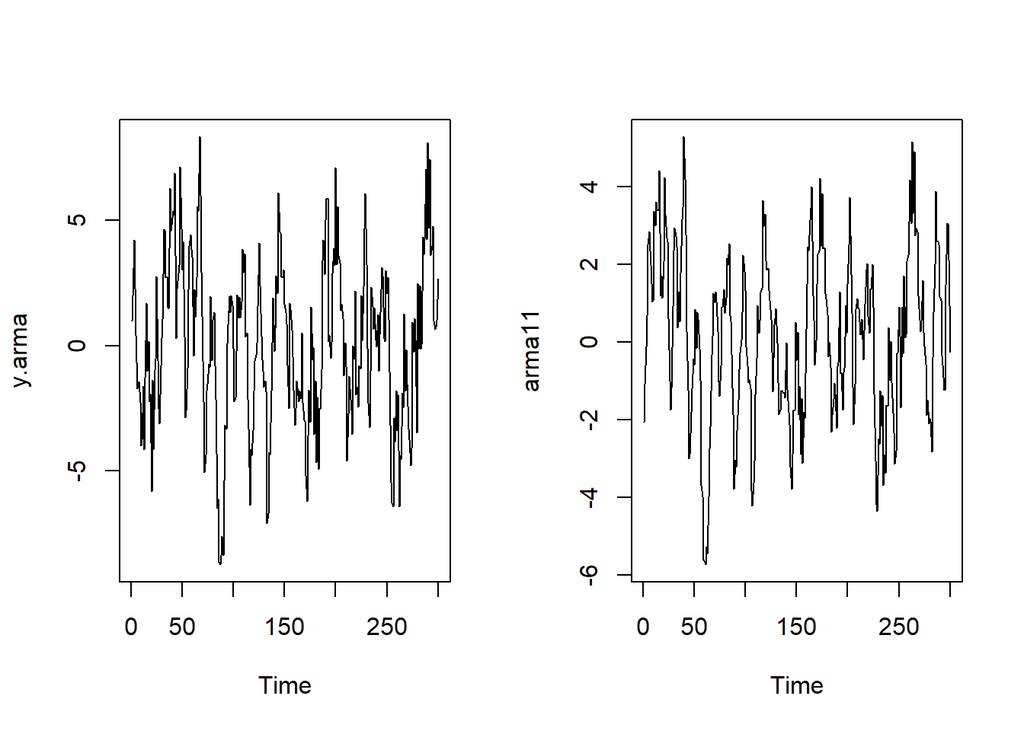

```r
par(mfrow = c(1, 2))
ts.plot(y.arma)
ts.plot(arma11)
```

```r
par(mfrow = c(1, 1))
```

### Plot ACF

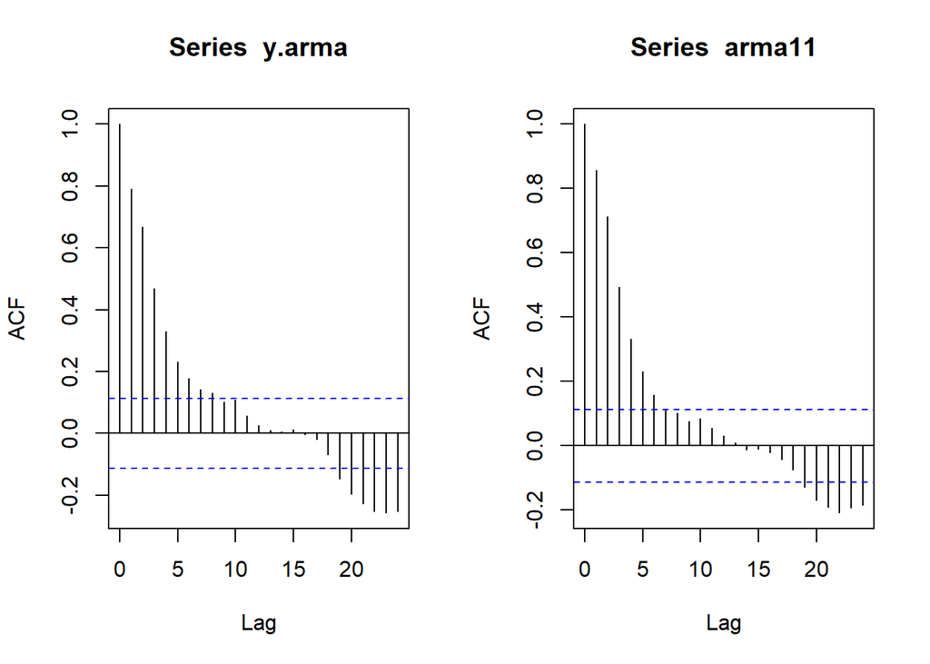

```r
par(mfrow = c(1, 2))
acf(y.arma)
acf(arma11)
```

```r
par(mfrow = c(1, 1))
```

### Plot PACF

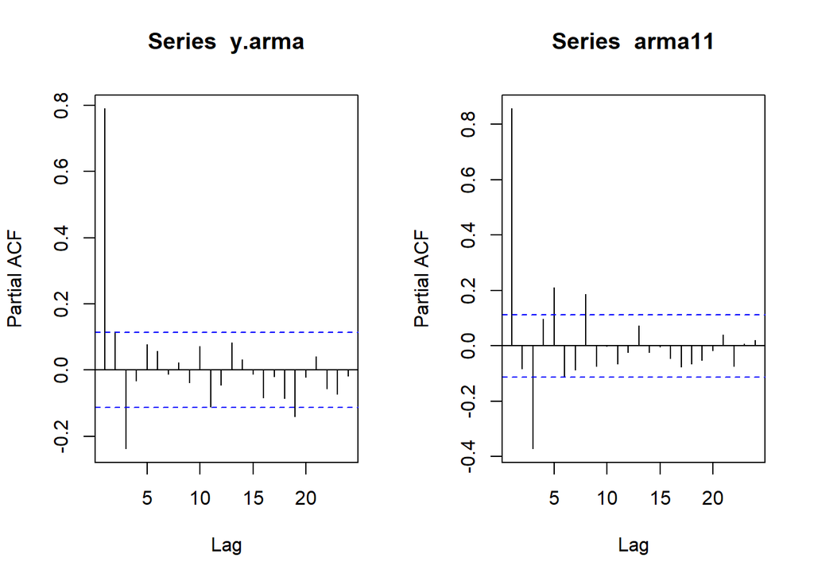

```r
par(mfrow = c(1, 2))
pacf(y.arma)
pacf(arma11)
```

```r
par(mfrow = c(1, 1))
```

### Plot EACF

```r
TSA::eacf(y.arma)
```

```
## AR/MA
##   0 1 2 3 4 5 6 7 8 9 10 11 12 13
## 0 x x x x x x x x o o o  o  o  o
## 1 x x o o o o o o o x o  o  o  o
## 2 x x o o o o o o o x o  o  o  o
## 3 x x o o o o o o o x o  o  o  o
## 4 x x o x o o o o o x o  o  o  o
## 5 x x o o o o o o o o o  o  o  o
## 6 x x o x o o o o o x o  o  o  o
## 7 x o o o o o o o o x o  o  o  o
```

```r
TSA::eacf(arma11)
```

```
## AR/MA
##   0 1 2 3 4 5 6 7 8 9 10 11 12 13
## 0 x x x x x x o o o o o  o  o  o
## 1 o x o o o o x o o x o  o  o  o
## 2 x x x o o o o o o x o  o  o  o
## 3 x x x o o o o o o x o  o  o  o
## 4 x x x o o o o o o x o  o  o  o
## 5 x x x o o x o o o x o  o  o  o
## 6 x x o x o x o o o x o  o  o  o
## 7 x x o x o x o x o o o  o  o  o
```

Berdasarkan pola segitiga nol pada plot EACF, terlihat bahwa segitiga nol berada pada ordo AR(1) dan ordo MA(2)

### Scatterplot Antar Lag

#### Scatterplot antara $Y_t$ dengan $Y_{t-1}$

```r
#Yt
yt_arma <- arma11[-c(1,2)]
yt_arma
```

```
##   [1] -0.118709697  0.694350070  2.514125307  2.843714001  2.357414501
##   [6]  1.984089114  1.038910602  1.076444380  3.375914225  2.991975652
##  [11]  3.607101243  3.404378952  3.380325072  4.404570791  1.198960085
##  [16]  1.697156349  1.130001200  2.076435923  4.239467277  3.270733130
##  [21]  2.677872987  2.580459145  0.611698649 -1.000860410 -1.746089847
##  [26] -1.166860419  0.926653912  2.342232902  2.940723989  2.725104974
##  [31]  2.451145357  0.367806585  1.302743645  0.530022188  1.775543148
##  [36]  3.158706113  3.465835692  5.280889053  4.193580373  2.761914900
##  [41]  0.269179767 -1.235434335 -2.991649935 -2.886684324 -1.806717566
##  [46] -1.200011944 -0.436402039 -0.588496528  0.838257537 -0.148872168
##  [51]  0.769162539  0.590806005 -0.176974963 -0.969218207 -3.672448074
##  [56] -3.980569859 -5.603801490 -5.627247489 -5.722283703 -5.273687748
##  [61] -5.443076916 -3.978637236 -2.747540834 -2.175391364 -0.323757180
##  [66]  0.152854619  1.248659548  1.016535386  1.286764005  1.040463565
##  [71]  0.280418067 -1.027465293 -1.389259653 -0.613024388  0.894720321
```

[output cut: 45 more lines]

```r
#Yt-1
yt_1_arma <- arma11[-c(299,300)]
yt_1_arma
```

```
##   [1] -2.053338467 -1.076228973 -0.118709697  0.694350070  2.514125307
##   [6]  2.843714001  2.357414501  1.984089114  1.038910602  1.076444380
##  [11]  3.375914225  2.991975652  3.607101243  3.404378952  3.380325072
##  [16]  4.404570791  1.198960085  1.697156349  1.130001200  2.076435923
##  [21]  4.239467277  3.270733130  2.677872987  2.580459145  0.611698649
##  [26] -1.000860410 -1.746089847 -1.166860419  0.926653912  2.342232902
##  [31]  2.940723989  2.725104974  2.451145357  0.367806585  1.302743645
##  [36]  0.530022188  1.775543148  3.158706113  3.465835692  5.280889053
##  [41]  4.193580373  2.761914900  0.269179767 -1.235434335 -2.991649935
##  [46] -2.886684324 -1.806717566 -1.200011944 -0.436402039 -0.588496528
##  [51]  0.838257537 -0.148872168  0.769162539  0.590806005 -0.176974963
##  [56] -0.969218207 -3.672448074 -3.980569859 -5.603801490 -5.627247489
##  [61] -5.722283703 -5.273687748 -5.443076916 -3.978637236 -2.747540834
##  [66] -2.175391364 -0.323757180  0.152854619  1.248659548  1.016535386
##  [71]  1.286764005  1.040463565  0.280418067 -1.027465293 -1.389259653
```

[output cut: 45 more lines]

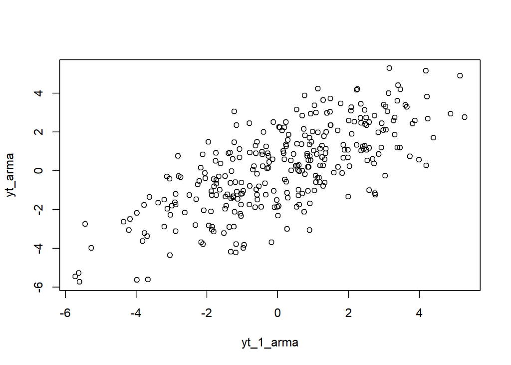

```r
plot(y=yt_arma,x=yt_1_arma)
```

Berdasarkan scatterplot tersebut, terlihat bahwa terdapat hubungan positif antara $Y_t$ dengan $Y_{t-1}$. Hal ini sesuai dengan teori yang ada

#### Scatterplot antara $Y_t$ dengan $Y_{t-2}$

```r
#Yt
yt_arma2 <- arma11[-c(1,2,3)]
yt_arma2
```

```
##   [1]  0.694350070  2.514125307  2.843714001  2.357414501  1.984089114
##   [6]  1.038910602  1.076444380  3.375914225  2.991975652  3.607101243
##  [11]  3.404378952  3.380325072  4.404570791  1.198960085  1.697156349
##  [16]  1.130001200  2.076435923  4.239467277  3.270733130  2.677872987
##  [21]  2.580459145  0.611698649 -1.000860410 -1.746089847 -1.166860419
##  [26]  0.926653912  2.342232902  2.940723989  2.725104974  2.451145357
##  [31]  0.367806585  1.302743645  0.530022188  1.775543148  3.158706113
##  [36]  3.465835692  5.280889053  4.193580373  2.761914900  0.269179767
##  [41] -1.235434335 -2.991649935 -2.886684324 -1.806717566 -1.200011944
##  [46] -0.436402039 -0.588496528  0.838257537 -0.148872168  0.769162539
##  [51]  0.590806005 -0.176974963 -0.969218207 -3.672448074 -3.980569859
##  [56] -5.603801490 -5.627247489 -5.722283703 -5.273687748 -5.443076916
##  [61] -3.978637236 -2.747540834 -2.175391364 -0.323757180  0.152854619
##  [66]  1.248659548  1.016535386  1.286764005  1.040463565  0.280418067
##  [71] -1.027465293 -1.389259653 -0.613024388  0.894720321  0.906915927
```

[output cut: 45 more lines]

```r
#Yt-2
yt_2_arma <- arma11[-c(298,299,300)]
yt_2_arma
```

```
##   [1] -2.053338467 -1.076228973 -0.118709697  0.694350070  2.514125307
##   [6]  2.843714001  2.357414501  1.984089114  1.038910602  1.076444380
##  [11]  3.375914225  2.991975652  3.607101243  3.404378952  3.380325072
##  [16]  4.404570791  1.198960085  1.697156349  1.130001200  2.076435923
##  [21]  4.239467277  3.270733130  2.677872987  2.580459145  0.611698649
##  [26] -1.000860410 -1.746089847 -1.166860419  0.926653912  2.342232902
##  [31]  2.940723989  2.725104974  2.451145357  0.367806585  1.302743645
##  [36]  0.530022188  1.775543148  3.158706113  3.465835692  5.280889053
##  [41]  4.193580373  2.761914900  0.269179767 -1.235434335 -2.991649935
##  [46] -2.886684324 -1.806717566 -1.200011944 -0.436402039 -0.588496528
##  [51]  0.838257537 -0.148872168  0.769162539  0.590806005 -0.176974963
##  [56] -0.969218207 -3.672448074 -3.980569859 -5.603801490 -5.627247489
##  [61] -5.722283703 -5.273687748 -5.443076916 -3.978637236 -2.747540834
##  [66] -2.175391364 -0.323757180  0.152854619  1.248659548  1.016535386
##  [71]  1.286764005  1.040463565  0.280418067 -1.027465293 -1.389259653
```

[output cut: 45 more lines]

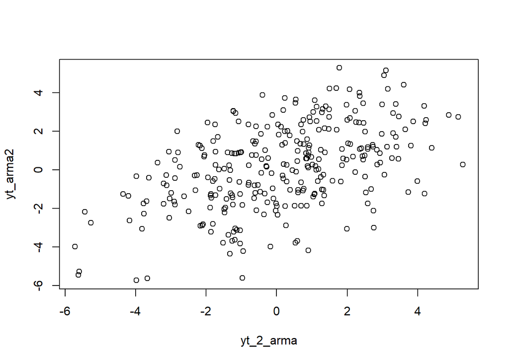

```r
plot(y=yt_arma2,x=yt_2_arma)
```

Berdasarkan scatterplot tersebut, terlihat bahwa terdapat hubungan positif antara $Y_t$ dengan $Y_{t-2}$. Hal ini sesuai dengan teori yang ada

#### Scatterplot antara $Y_t$ dengan $Y_{t-3}$

```r
#Yt
yt_arma3 <- arma11[-c(1,2,3,4)]
yt_arma3
```

```
##   [1]  2.514125307  2.843714001  2.357414501  1.984089114  1.038910602
##   [6]  1.076444380  3.375914225  2.991975652  3.607101243  3.404378952
##  [11]  3.380325072  4.404570791  1.198960085  1.697156349  1.130001200
##  [16]  2.076435923  4.239467277  3.270733130  2.677872987  2.580459145
##  [21]  0.611698649 -1.000860410 -1.746089847 -1.166860419  0.926653912
##  [26]  2.342232902  2.940723989  2.725104974  2.451145357  0.367806585
##  [31]  1.302743645  0.530022188  1.775543148  3.158706113  3.465835692
##  [36]  5.280889053  4.193580373  2.761914900  0.269179767 -1.235434335
##  [41] -2.991649935 -2.886684324 -1.806717566 -1.200011944 -0.436402039
##  [46] -0.588496528  0.838257537 -0.148872168  0.769162539  0.590806005
##  [51] -0.176974963 -0.969218207 -3.672448074 -3.980569859 -5.603801490
##  [56] -5.627247489 -5.722283703 -5.273687748 -5.443076916 -3.978637236
##  [61] -2.747540834 -2.175391364 -0.323757180  0.152854619  1.248659548
##  [66]  1.016535386  1.286764005  1.040463565  0.280418067 -1.027465293
##  [71] -1.389259653 -0.613024388  0.894720321  0.906915927  1.356802698
```

[output cut: 45 more lines]

```r
#Yt-2
yt_3_arma <- arma11[-c(297,298,299,300)]
yt_3_arma
```

```
##   [1] -2.053338467 -1.076228973 -0.118709697  0.694350070  2.514125307
##   [6]  2.843714001  2.357414501  1.984089114  1.038910602  1.076444380
##  [11]  3.375914225  2.991975652  3.607101243  3.404378952  3.380325072
##  [16]  4.404570791  1.198960085  1.697156349  1.130001200  2.076435923
##  [21]  4.239467277  3.270733130  2.677872987  2.580459145  0.611698649
##  [26] -1.000860410 -1.746089847 -1.166860419  0.926653912  2.342232902
##  [31]  2.940723989  2.725104974  2.451145357  0.367806585  1.302743645
##  [36]  0.530022188  1.775543148  3.158706113  3.465835692  5.280889053
##  [41]  4.193580373  2.761914900  0.269179767 -1.235434335 -2.991649935
##  [46] -2.886684324 -1.806717566 -1.200011944 -0.436402039 -0.588496528
##  [51]  0.838257537 -0.148872168  0.769162539  0.590806005 -0.176974963
##  [56] -0.969218207 -3.672448074 -3.980569859 -5.603801490 -5.627247489
##  [61] -5.722283703 -5.273687748 -5.443076916 -3.978637236 -2.747540834
##  [66] -2.175391364 -0.323757180  0.152854619  1.248659548  1.016535386
##  [71]  1.286764005  1.040463565  0.280418067 -1.027465293 -1.389259653
```

[output cut: 45 more lines]

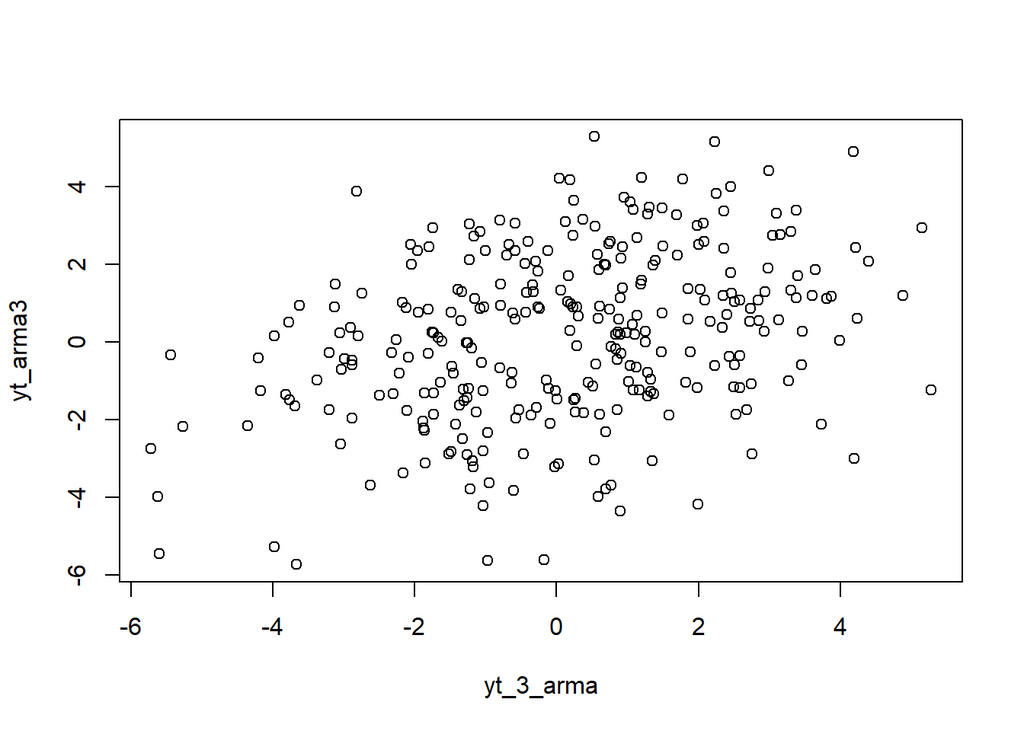

```r
plot(y=yt_arma3,x=yt_3_arma)
```

Berdasarkan scatterplot tersebut, terlihat bahwa terdapat hubungan positif antara $Y_t$ dengan $Y_{t-3}$. Hal ini sesuai dengan teori yang ada